# Reproducible Research - Assignment 1

Gopi Shanmugam

February 21, 2017

# Reproducible Research - Assignment 1

## Loading and preprocessing the data

```r
library(dplyr)
```

```r
library(ggplot2)
raw_data <- read.csv("../../workingdir/activity_data/activity.csv", header = TRUE, sep = ",")

head(raw_data)
```

```
##   steps       date interval
## 1    NA 2012-10-01        0
## 2    NA 2012-10-01        5
## 3    NA 2012-10-01       10
## 4    NA 2012-10-01       15
## 5    NA 2012-10-01       20
## 6    NA 2012-10-01       25
```

```r
str(raw_data)
```

```
## 'data.frame':    17568 obs. of  3 variables:
##  $ steps   : int  NA NA NA NA NA NA NA NA NA NA ...
##  $ date    : Factor w/ 61 levels "2012-10-01","2012-10-02",..: 1 1 1 1 1 1 1 1 1 1 ...
##  $ interval: int  0 5 10 15 20 25 30 35 40 45 ...
```

## What is mean total number of steps taken per day?

The total number of steps taken by the subject per day:

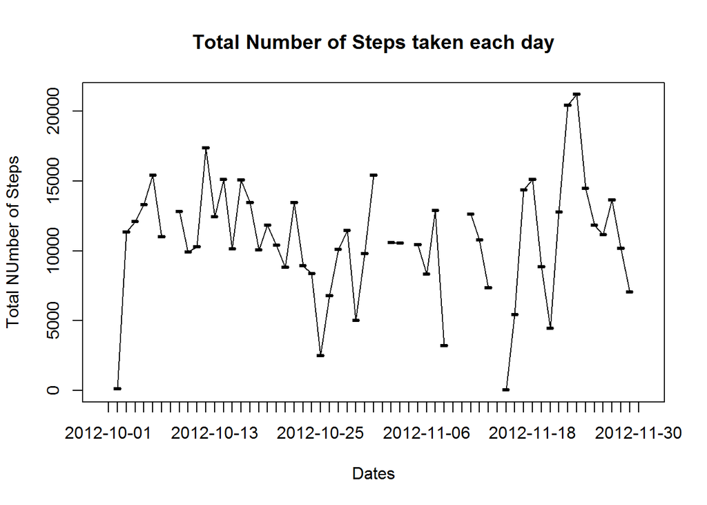

```r
daily_totals <- aggregate(steps ~ date, raw_data, sum, na.action = na.pass)

plot(daily_totals$date,daily_totals$steps, xlab="Dates", ylab="Total NUmber of Steps", main="Total Number of Steps taken each day")
lines(daily_totals$date,daily_totals$steps)
```

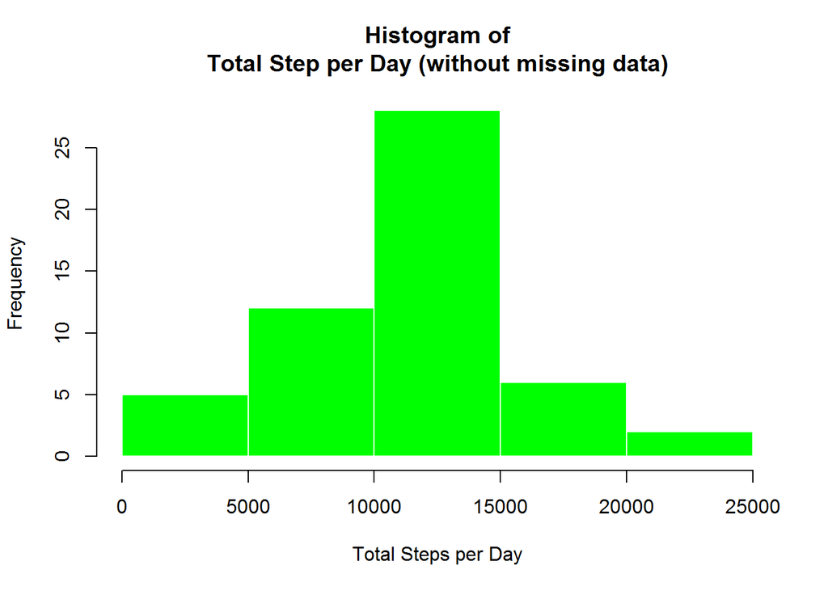

```r
hist(daily_totals$steps, main="Histogram of\nTotal Step per Day (without missing data)", xlab="Total Steps per Day", col = "green", border = "white")
```

The Mean and Median of the Daily Steps Total will need to be calculated after the “NA” values are removed.

```r
mean(daily_totals$steps, na.rm = TRUE)
```

```
## [1] 10766.19
```

```r
median(daily_totals$steps, na.rm = TRUE)
```

```
## [1] 10765
```

## What is the average daily activity pattern?

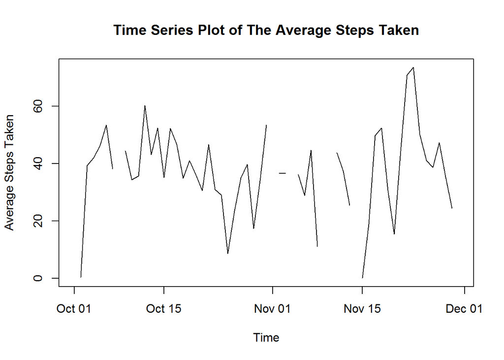

```r
raw_data$date <- as.Date(raw_data$date)
summary.dat <- group_by(raw_data,date)
summary.dat <- summarise(summary.dat, Mean=mean(steps),Median=median(steps),Min=min(steps),Max=max(steps))

summary.dat <- cbind(summary.dat,total_steps=daily_totals$steps)

plot(summary.dat$date,summary.dat$Mean, type = "l",
     main = "Time Series Plot of The Average Steps Taken",
     xlab = "Time", ylab = "Average Steps Taken", col="red")
lines(summary.dat$date,summary.dat$Mean)
```

The 5-minute interval, on average across all the days in the dataset, that contains the maximum number of steps is:

```r
ave <- aggregate(x = list(steps = raw_data$steps), by = list(interval = raw_data$interval), FUN = mean, na.rm = TRUE)

print("The maximum number of steps on average occured on the following Interval:")
```

```
## [1] "The maximum number of steps on average occured on the following Interval:"
```

```r
ave[which.max(ave$steps),]
```

```
##     interval    steps
## 104      835 206.1698
```

## Imputing missing values

Just like in any real world data, there will be cases where values are missing. We have to handle these situation by filling in the missing data in a logical way. In the case of this assignment, it seems most appropriate if the missing data for a particular interval is replaced by the average (mean) value for that interval

```r
imp_data <- raw_data

print("Number of Rows with missing data:")
```

```
## [1] "Number of Rows with missing data:"
```

```r
sum(is.na(imp_data$steps))
```

```
## [1] 2304
```

Replacement of missing values with the Mean value for that respective interval

```r
for (i in 1:nrow(imp_data)){
  if (is.na(imp_data[i,1])) {
    imp_data[i,1] <- ave[ave$interval==imp_data[i,3],2]
  }
}
```

Now we can compare the data before and after the imputing of missing data

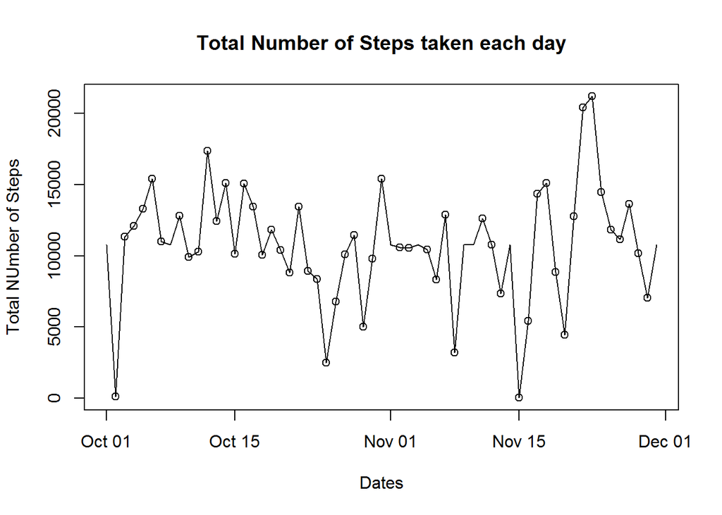

```r
imp_totals <- aggregate(steps ~ date, imp_data, sum, na.action = na.pass)

plot(imp_totals$date,daily_totals$steps, xlab="Dates", ylab="Total NUmber of Steps", main="Total Number of Steps taken each day")
lines(imp_totals$date,imp_totals$steps)
```

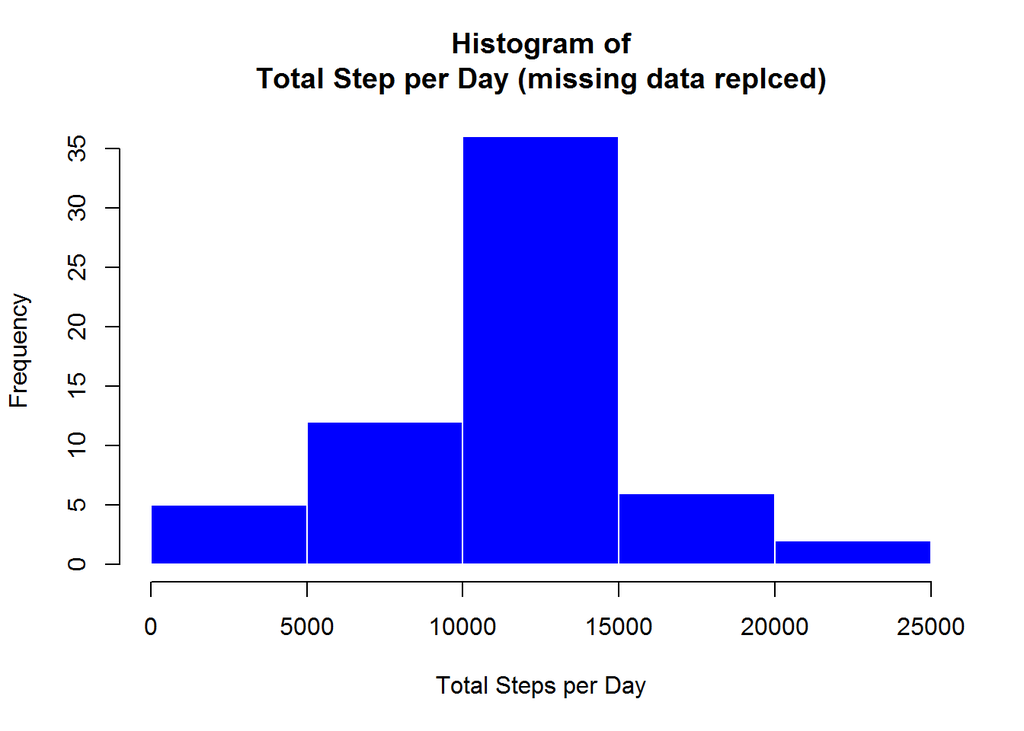

```r
hist(imp_totals$steps, main="Histogram of\nTotal Step per Day (missing data replced)", xlab="Total Steps per Day", col = "blue", border = "white")
```

## Are there differences in activity patterns between weekdays and weekends?

Now we segment the data between the Weekdays and Weekends; to determine if there is a difference in activity levels between the two time periods.

```r
imp_data$date <- as.Date(imp_data$date)
imp_data$daytype <- ""
for (i in 1:nrow(imp_data)){
  day <- weekdays(imp_data$date[i])
  if (day %in% c("Monday", "Tuesday", "Wednesday", "Thursday", "Friday")) {
    imp_data$daytype[i] <- "Weekday"
    }
  else if (day %in% c("Saturday", "Sunday")){
    imp_data$daytype[i] <- "Weekend"
    }
  else stop("Invalid Date")
}
```

Now we calculate the average steps for each interval

```r
imp_ave <- aggregate(steps ~ interval + daytype, data = imp_data, mean)
```

Let’s see what the plot of the average steps taken in each interval across the weekdays and weekends.

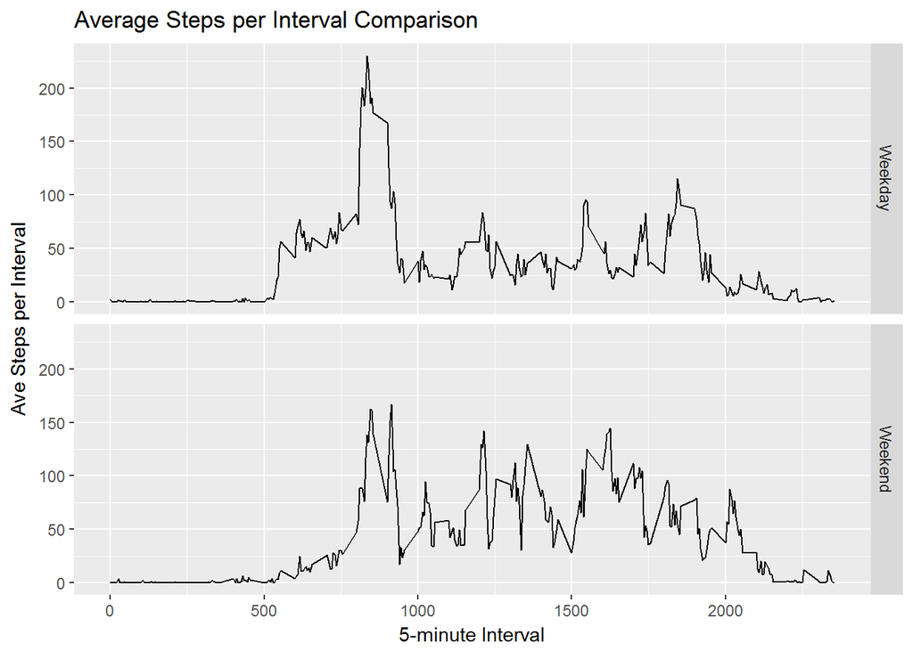

```r
grph <- ggplot(imp_ave, aes(x=interval, y=steps))
grph <- grph + geom_line()
grph <- grph + facet_grid(daytype ~ .)
grph <- grph + labs(x="5-minute Interval", y="Ave Steps per Interval")
grph <- grph + labs(title="Average Steps per Interval Comparison")

print(grph)
```